# Testing the Stroop Effect

Mohamed Khodeir

December 12, 2015

## References

[1] http://www.biostathandbook.com/pairedttest.html

[2] http://oak.ucc.nau.edu/rh232/courses/EPS525/Handouts/Understanding%20the%20Dependent%20t%20Test.pdf

## Questions

**What is an appropriate set of hypotheses for this task? What kind of statistical test do you expect to perform? Justify your choices.**

An appropriate null hypothesis is that there is no difference in the time taken to name all the colors in the list. Since the data are paired (each subject is present in both the congruent and incongruent groups) and are thus dependent or correlated, it is necessary to use a paired difference test.

If we think of the data as being the set of difference scores, the null hypothesis becomes the hypothesis that the mean of a population of difference scores (denoted $\mu_{difference}$) equals 0. [2]

Thus the null hypothesis is: $H_0 : \mu_{difference} = \mu_{incongruent} - \mu_{congruent} = 0$

A good alternative hypothesis is that it takes longer to name the colors in the incongruous condition - that was the case for my attempt. In this case I would perform a one-tailed test. Depending on the distribution of the data, I would use either a t-test or a non-parametric test such as the Wilcoxon signed-rank test.

ie. $H_1 : \mu_{difference} = \mu_{incongruent} - \mu_{congruent} > 0$

**Report some descriptive statistics regarding this dataset. Include at least one measure of central tendency and at least one measure of variability.**

Because we can effectively view our matched-pairs hypothesis test as a one-sample test of the difference, i will only consider descriptive statistics of the set of differences ($t_{incongruent} - t_{congruent}$).

```
## Mean:                7.965
## Median:              7.666
## Standard Deviation:  4.865
```

**Provide one or two visualizations that show the distribution of the sample data. Write one or two sentences noting what you observe about the plot or plots.***

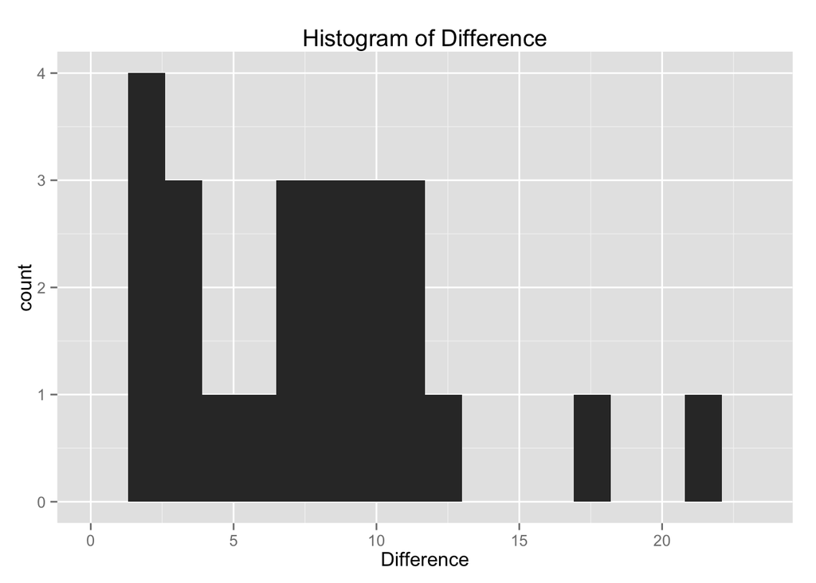

The limited size of the dataset makes analysing the distribution slightly problematic. However, the histogram shows some positive skew, with the right tail being longer. Also the distribution seems slightly bi-modal with two peaks.

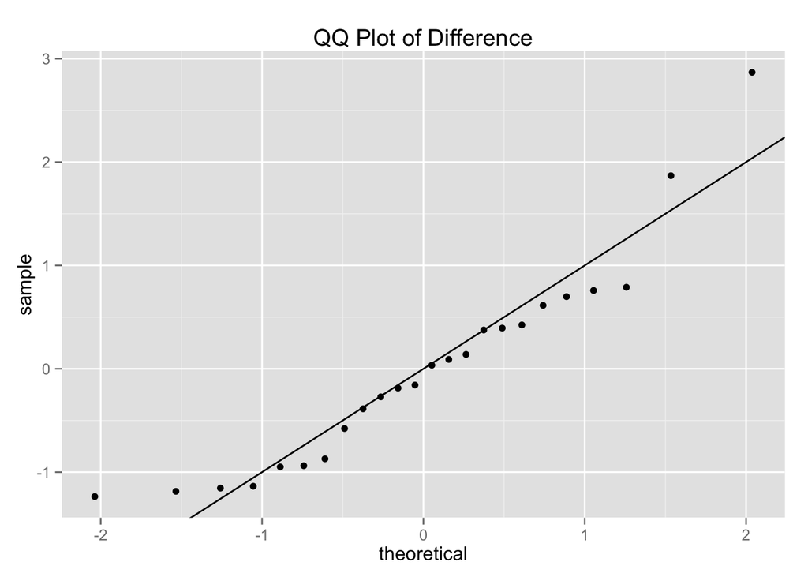

The qq-plot shows some deviations from normality. Again, we see the longer right tail and shorter left tail.

**Now, perform the statistical test and report your results. What is your confidence level and your critical statistic value? Do you reject the null hypothesis or fail to reject it? Come to a conclusion in terms of the experiment task. Did the results match up with your expectations?**

I think it would be safer to use the non-parametric test since the assumption of normality for the difference of the paired samples does not seem reasonable.

I will use an alpha level of .05.

```
##
##  Wilcoxon signed rank test
##
## data:  data$Difference
## V = 300, p-value = 5.96e-08
## alternative hypothesis: true location is greater than 0
```

Since $p = 5.96e-08 < .05$ then I would have to reject the null hypothesis in favor if the alternative hypothesis. Namely, that the incongruent condition really takes the subjects more time to complete.

This result is as expected. My own time for the incongruent condition was at least 8 seconds longer. The effect of the distraction of conflicting information from text and color seems very noticable.